# 算法训练营Day 10

Author

Siru Wu

Published

January 25, 2026

## 栈的一些基本知识：

- 栈只允许在同一端进行操作，这一端叫 栈顶（top）。
- 常见操作有：
- **入栈（push）**：把元素放到栈顶
- **出栈（pop）**：把栈顶元素拿走
- **查看栈顶（peek / top）**：看一下栈顶是谁，但不拿走
- **判空（isEmpty）**：栈是不是空的

## [232.用栈实现队列](https://leetcode.cn/problems/implement-queue-using-stacks/description/)

> 请你仅使用两个栈实现先入先出队列。队列应当支持一般队列支持的所有操作（push、pop、peek、empty）：

> 实现 MyQueue 类：
> - void push(int x) 将元素 x 推到队列的末尾
> - int pop() 从队列的开头移除并返回元素
> - int peek() 返回队列开头的元素
> - boolean empty() 如果队列为空，返回 true ；否则，返回 false 说明：

> 你 **只能** 使用标准的栈操作 —— 也就是只有 push to top, peek/pop from top, size, 和 is empty 操作是合法的。

> 你所使用的语言也许不支持栈。你可以使用 list 或者 deque（双端队列）来模拟一个栈，只要是标准的栈操作即可。

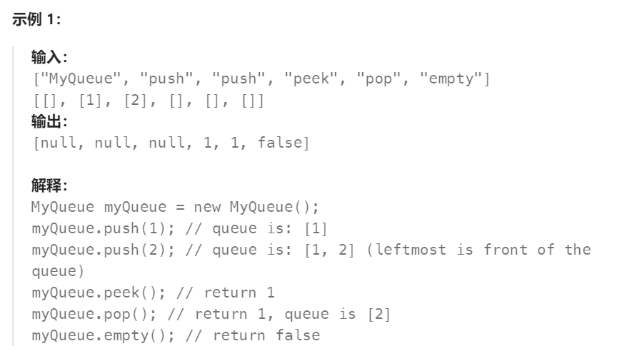

```python
# 队列这种数据结构不是“只能用一次”。
# 题目里的 MyQueue 是一个对象，我们会对它反复调用 push / pop / peek，所以当然会出现第二次、第三次 pop。
# 因此我们要有一个 if self.stack_out 来防止 已经排好队的元素被重复倒一次
class MyQueue(object):

    def __init__(self):
        self.stack_in = []
        self.stack_out = []

    def push(self, x):
        """
        :type x: int
        :rtype: None
        """
        self.stack_in.append(x)

    def pop(self):
        """
        :rtype: int
        """
        if self.empty():
            return None

        # 这个地方是用来 防止已经排好队的元素被重复倒一次
        if self.stack_out: # 如果 stack_out 不为空
            return self.stack_out.pop()
        else:
            for i in range(len(self.stack_in)):
                self.stack_out.append(self.stack_in.pop())
            return self.stack_out.pop()


    def peek(self):
        """
        :rtype: int
        """
        if self.empty():
            return None
        self._move()
        return self.stack_out[-1]   # 只看，不弹出

        # 底下这个写法有点隐患
        # 如果队列是空的，这里的 pop() 会返回 None，然后又把 None append 进 stack_out，队列就被污染了
        # ans = self.pop()
        # self.stack_out.append(ans)
        # return ans

    def empty(self):
        """
        :rtype: bool
        """
        return not (self.stack_in or self.stack_out)  # not + () 判断这两个stack里面是否有空值

# Your MyQueue object will be instantiated and called as such:
# obj = MyQueue()
# obj.push(x)
# param_2 = obj.pop()
# param_3 = obj.peek()
# param_4 = obj.empty()
```

## [225. 用队列实现栈](https://leetcode.cn/problems/implement-stack-using-queues/description/)

> 请你仅使用两个队列实现一个后入先出（LIFO）的栈，并支持普通栈的全部四种操作（push、top、pop 和 empty）。

> 实现 MyStack 类：
> - void push(int x) 将元素 x 压入栈顶。
> - int pop() 移除并返回栈顶元素。
> - int top() 返回栈顶元素。
> - boolean empty() 如果栈是空的，返回 true ；否则，返回 false 。

> 注意：

> 你只能使用队列的标准操作 —— 也就是 push to back、peek/pop from front、size 和 is empty 这些操作。

> 你所使用的语言也许不支持队列。 你可以使用 list （列表）或者 deque（双端队列）来模拟一个队列 , 只要是标准的队列操作即可。

```python
from collections import deque

class MyStack(object):
    """
    LeetCode 225: Implement Stack using Queues
    用“队列”来实现“栈”。

    1) 栈 Stack 的特点：LIFO（Last In First Out）后进先出
       - push(x): 把元素压入栈顶
       - pop():   弹出并返回栈顶元素
       - top():   返回栈顶元素（只看不删）
       - empty(): 判断栈是否为空

    2) 队列 Queue 的特点：FIFO（First In First Out）先进先出
       - append(x): 从队尾入队
       - popleft(): 从队头出队

    3) 本题限制：只能用“队列操作”来模拟“栈操作”
       所以我们不能直接像真正的栈那样 O(1) 找到“最后压入的元素”
       需要通过“搬运元素”来把最后一个元素单独拿出来。

    4) 为什么用 deque：
       - deque.popleft() 是 O(1)，适合做队列
       - list.pop(0) 是 O(n)，会整体移动元素，很慢
    """

    def __init__(self):
        """
        准备两个队列（双端队列 deque）：
        - quene_in：主队列，平时负责“存放所有元素”
        - quene_out：辅助队列，只在 pop/top 时用于“中转搬运”

        设计原则（非常重要）：
        - 正常情况下，所有数据都在 quene_in
        - quene_out 只在 pop/top 过程中临时使用，操作结束后通常会变空
        """
        self.quene_in = deque()
        self.quene_out = deque()

    def push(self, x):
        """
        push(x)：模拟“压栈”
        栈的 push 是把元素放到“栈顶”。

        但我们底层用的是队列：
        - 队列 append(x) 是从右边（队尾）加入

        在这个实现里，我们让 push 尽量简单：
        - 直接把 x 放进 quene_in 的队尾即可

        复杂的“变成栈顶”这件事，留到 pop/top 时再处理。

        时间复杂度：O(1)
        """
        self.quene_in.append(x)

    def pop(self):
        """
        pop()：模拟“弹出栈顶元素”
        栈顶元素 = 最后 push 进去的元素（LIFO）

        但是队列只能从队头 popleft() 取元素（FIFO）
        所以我们要做一件事：
        - 把 quene_in 里前面 n-1 个元素先搬走
        - 只留下最后 1 个元素（它就是“栈顶”）
        - 再把这个“栈顶”弹出并返回

        具体步骤（假设 quene_in 里有 [1,2,3,4]，4 是栈顶）：

        Step 0: 初始
            quene_in  = [1,2,3,4]
            quene_out = []

        Step 1: 搬运前 n-1 个元素到 quene_out
            quene_out = [1,2,3]
            quene_in  = [4]          # 只剩最后一个元素

        Step 2: 交换 in/out，让 quene_in 继续成为“主队列”
            交换后：
            quene_in  = [1,2,3]      # 剩余元素留在主队列
            quene_out = [4]          # 栈顶元素在辅助队列里

        Step 3: 弹出 quene_out 的队头（其实就是那唯一的元素 4）
            return 4

        时间复杂度：O(n)（需要搬运 n-1 个元素）
        """
        # 1) 先判断是否为空
        if self.empty():
            return None

        # 2) 搬运 n-1 个元素：把前面的都挪走，只留下“最后一个”
        #    range(len(self.quene_in) - 1) 表示循环 n-1 次
        for _ in range(len(self.quene_in) - 1):
            self.quene_out.append(self.quene_in.popleft())

        # 3) 交换，让 quene_in 始终负责“保存剩余所有元素”
        self.quene_in, self.quene_out = self.quene_out, self.quene_in

        # 4) 此时 quene_out 里只有原来的“最后一个元素”（栈顶）
        #    直接弹出并返回
        return self.quene_out.popleft()

    def top(self):
        """
        top()：返回栈顶元素（只看不删）

        top 和 pop 很像，区别只有一句话：
        - pop：拿到栈顶后，直接删除
        - top：拿到栈顶后，要放回去，保证栈内容不变

        同样假设 quene_in 初始为 [1,2,3,4]，4 是栈顶：

        Step 0: 初始
            quene_in  = [1,2,3,4]
            quene_out = []

        Step 1: 搬运前 n-1 个元素到 quene_out
            quene_out = [1,2,3]
            quene_in  = [4]

        Step 2: 交换 in/out
            quene_in  = [1,2,3]
            quene_out = [4]

        Step 3: 取出栈顶元素 temp（但不能丢掉）
            temp = 4
            quene_out = []

        Step 4: 把 temp 放回 quene_in 的末尾
            quene_in = [1,2,3,4]
            这样就恢复成 top() 之前的状态

        Step 5: return temp

        时间复杂度：O(n)
        """
        # 1) 先判断是否为空
        if self.empty():
            return None

        # 2) 搬运 n-1 个元素，把“最后一个元素”单独留下
        for _ in range(len(self.quene_in) - 1):
            self.quene_out.append(self.quene_in.popleft())

        # 3) 交换，让 quene_in 继续保存剩余所有元素
        self.quene_in, self.quene_out = self.quene_out, self.quene_in

        # 4) 取出栈顶元素（此时 quene_out 只有这一个元素）
        temp = self.quene_out.popleft()

        # 5) 注意：top 是“只看不删”，所以要把它放回主队列末尾
        self.quene_in.append(temp)

        # 6) 返回栈顶
        return temp

    def empty(self):
        """
        empty()：判断栈是否为空

        因为我们的设计是：
        - 所有真实数据都放在 quene_in
        - quene_out 只是 pop/top 时临时中转

        所以判断 quene_in 是否为空即可。

        时间复杂度：O(1)
        """
        return len(self.quene_in) == 0

# Your MyStack object will be instantiated and called as such:
# obj = MyStack()
# obj.push(x)
# param_2 = obj.pop()
# param_3 = obj.top()
# param_4 = obj.empty()
```

## 20 有效的括号

> 给定一个只包括 ‘(’，‘)’，‘{’，‘}’，‘[’，’]’ 的字符串 s ，判断字符串是否有效。

> 有效字符串需满足：

> 左括号必须用相同类型的右括号闭合。

> 左括号必须以正确的顺序闭合。

> 每个右括号都有一个对应的相同类型的左括号。

> **示例 1：**
> - 输入：s = “()”
> - 输出：true

> **示例 2：**
> - 输入：s = “()”
> - 输出：true

> **示例 3：**
> - 输入：s = “(]”
> - 输出：false

> **示例 4：**
> - 输入：s = “([])”
> - 输出：true

> **示例 5：**
> - 输入：s = “([)]”
> - 输出：false

> 提示：

> 1 <= s.length <= 104 s 仅由括号 ‘()’ 组成

### # 方法一，仅使用栈

```python
class Solution:
    def isValid(self, s: str) -> bool:
        stack = []

        # stack里面只会存我们想要的东西 ), }, ]
        # 如果最后栈不空, 👉 说明 有左括号没等到右括号
        # 如果中途右括号多出来,👉 说明 有右括号没有对应左括号
        for item in s:
            if item == '(':
                stack.append(')')
            elif item == '[':
                stack.append(']')
            elif item == '{':
                stack.append('}')
            elif not stack or stack[-1] != item: # not stack的意思是stack为空
                return False
            else:
                stack.pop() # 如果左括号找到右括号了，就把我们存的右括号从stack里面删掉
                # 我们最后如果希望所有的左括号都找到右括号了，就需要stack为空
                # 如果stack不为空的话，就说明有右括号没找到对应的左括号

        return True if not stack else False
```

## [1047. 删除字符串中的所有相邻重复项](https://leetcode.cn/problems/remove-all-adjacent-duplicates-in-string/description/)

> 给出由小写字母组成的字符串 s，重复项删除操作会选择两个相邻且相同的字母，并删除它们。

> 在 s 上反复执行重复项删除操作，直到无法继续删除。

> 在完成所有重复项删除操作后返回最终的字符串。答案保证唯一。

> **示例：**
> - 输入：“abbaca”
> - 输出：“ca”

> 解释：

> 例如，在 “abbaca” 中，我们可以删除 “bb” 由于两字母相邻且相同，这是此时唯一可以执行删除操作的重复项。之后我们得到字符串 “aaca”，其中又只有 “aa” 可以执行重复项删除操作，所以最后的字符串为 “ca”。

### 栈

```python
class Solution:
    def removeDuplicates(self, s: str) -> str:
        res = list()

        for item in s:
            # 这里 if 判断了两个条件
            # 1. if res: res里面是否有东西
            # 2. if res[-1] == item: res的栈顶是否和item一样
            if res and res[-1] == item:
                res.pop()
            else:
                res.append(item)
        return ''.join(res)
```

### 双指针解法

```python
class Solution:
    def removeDuplicates(self, s: str) -> str:
        res = list(s)
        # # 二者都从 0 开始，表示从第一个字符开始处理
        slow = fast = 0
        length = len(s)

        # # 当 fast 还没有读完整个字符串时，继续处理
        while fast < length:
            # 先假设当前字符 res[fast] 是有效的
            # 将它写入到 slow 位置
            res[slow] = res[fast]

            # 如果 slow > 0，说明前面已经有字符
            # 并且当前写入的字符和前一个字符相同, 说明出现了相邻重复
            if slow > 0 and res[slow] == res[slow - 1]:
                # 相邻重复需要删除
                # slow 回退一格
                slow -= 1

            else:
                # 没有重复，当前字符可以保留
                # 扩大有效结果区域
                slow += 1

            # fast 始终向前移动，读取下一个字符
            fast += 1

        # res[0:slow] 保存的是最终去重后的字符
        # 使用 join 将字符列表拼接成字符串返回
        return ''.join(res[0:slow])

        # res = [有效结果 | 垃圾区]
        #             ↑
       #            slow
```

done